# Predict Bike Sharing Demand with AutoGluon Template

## Project: Predict Bike Sharing Demand with AutoGluon

This notebook is a template with each step that you need to complete for the project.

Please fill in your code where there are explicit `?` markers in the notebook. You are welcome to add more cells and code as you see fit.

Once you have completed all the code implementations, please export your notebook as a HTML file so the reviews can view your code. Make sure you have all outputs correctly outputted.

`File-> Export Notebook As... -> Export Notebook as HTML`

There is a writeup to complete as well after all code implememtation is done. Please answer all questions and attach the necessary tables and charts. You can complete the writeup in either markdown or PDF.

Completing the code template and writeup template will cover all of the rubric points for this project.

The rubric contains "Stand Out Suggestions" for enhancing the project beyond the minimum requirements. The stand out suggestions are optional. If you decide to pursue the "stand out suggestions", you can include the code in this notebook and also discuss the results in the writeup file.

## Step 1: Create an account with Kaggle

### Create Kaggle Account and download API key

Below is example of steps to get the API username and key. Each student will have their own username and key.

1. Open account settings.

2. Scroll down to API and click Create New API Token.

3. Open up `kaggle.json` and use the username and key.


## Step 2: Download the Kaggle dataset using the kaggle python library

### Open up Sagemaker Studio and use starter template

1. Notebook should be using a `ml.t3.medium` instance (2 vCPU + 4 GiB)
2. Notebook should be using kernal: `Python 3 (MXNet 1.8 Python 3.7 CPU Optimized)`

### Install packages

```python
!pip install -U pip
!pip install -U setuptools wheel
!pip install -U "mxnet<2.0.0" bokeh==2.0.1
!pip install autogluon --no-cache-dir
# Without --no-cache-dir, smaller aws instances may have trouble installing
```

[output not shown]

[output cut: 11 more lines]

[output not shown]

```python
!pip install kaggle
```

```
  Using cached kaggle-1.6.17-py3-none-any.whl
```

```python
# # create the .kaggle directory and an empty kaggle.json file
# !mkdir -p /root/.kaggle
# !touch /root/.kaggle/kaggle.json
# !chmod 600 /root/.kaggle/kaggle.json
```

```python
# !sudo mkdir -p /root/.kaggle
# !sudo touch /root/.kaggle/kaggle.json
# !sudo chmod 600 /root/.kaggle/kaggle.json
```

```python
# # Fill in your user name and key from creating the kaggle account and API token file
# import json
# kaggle_username = "hongyilu"
# kaggle_key = "28415561bd8feee88e34c274230346d8"
#
# # Save API token the kaggle.json file
# with open("/root/.kaggle/kaggle.json", "w") as f:
#     f.write(json.dumps({"username": kaggle_username, "key": kaggle_key}))
```

```python
# # Fill in your user name and key from creating the kaggle account and API token file
# import json
# kaggle_username = "hongyilu"
# kaggle_key = "28415561bd8feee88e34c274230346d8"
#
# # Save API token the kaggle.json file
# with open("~/.kaggle/kaggle.json", "w") as f:
#     f.write(json.dumps({"username": kaggle_username, "key": kaggle_key}))
```

### Download and explore dataset

### Go to the bike sharing demand competition and agree to the terms

```python
# Download the dataset, it will be in a .zip file so you'll need to unzip it as well.
!kaggle competitions download -c bike-sharing-demand
# If you already downloaded it you can use the -o command to overwrite the file
!unzip -o bike-sharing-demand.zip
```

```
bike-sharing-demand.zip: Skipping, found more recently modified local copy (use --force to force download)
Archive:  bike-sharing-demand.zip
  inflating: sampleSubmission.csv
  inflating: test.csv
  inflating: train.csv
```

```python
import pandas as pd
from autogluon.tabular import TabularPredictor
import matplotlib.pyplot as plt
import seaborn as sns
import numpy as np
```

```python
# Suppress all the warning messages
import warnings
warnings.filterwarnings('ignore')
```

```python
# Create the train dataset in pandas by reading the csv
# Set the parsing of the datetime column so you can use some of the `dt` features in pandas later
train = pd.read_csv('train.csv', parse_dates=["datetime"])
print(train.shape)
train.head()
```

```
(10886, 12)
```

|  | datetime | season | holiday | workingday | weather | temp | atemp | humidity | windspeed | casual | registered | count |
| --- | --- | --- | --- | --- | --- | --- | --- | --- | --- | --- | --- | --- |
| 0 | 2011-01-01 00:00:00 | 1 | 0 | 0 | 1 | 9.84 | 14.395 | 81 | 0.0 | 3 | 13 | 16 |
| 1 | 2011-01-01 01:00:00 | 1 | 0 | 0 | 1 | 9.02 | 13.635 | 80 | 0.0 | 8 | 32 | 40 |
| 2 | 2011-01-01 02:00:00 | 1 | 0 | 0 | 1 | 9.02 | 13.635 | 80 | 0.0 | 5 | 27 | 32 |
| 3 | 2011-01-01 03:00:00 | 1 | 0 | 0 | 1 | 9.84 | 14.395 | 75 | 0.0 | 3 | 10 | 13 |
| 4 | 2011-01-01 04:00:00 | 1 | 0 | 0 | 1 | 9.84 | 14.395 | 75 | 0.0 | 0 | 1 | 1 |

```python
# Simple output of the train dataset to view some of the min/max/varition of the dataset features.
train.describe()
```

|  | datetime | season | holiday | workingday | weather | temp | atemp | humidity | windspeed | casual | registered | count |
| --- | --- | --- | --- | --- | --- | --- | --- | --- | --- | --- | --- | --- |
| count | 10886 | 10886.000000 | 10886.000000 | 10886.000000 | 10886.000000 | 10886.00000 | 10886.000000 | 10886.000000 | 10886.000000 | 10886.000000 | 10886.000000 | 10886.000000 |
| mean | 2011-12-27 05:56:22.399411968 | 2.506614 | 0.028569 | 0.680875 | 1.418427 | 20.23086 | 23.655084 | 61.886460 | 12.799395 | 36.021955 | 155.552177 | 191.574132 |
| min | 2011-01-01 00:00:00 | 1.000000 | 0.000000 | 0.000000 | 1.000000 | 0.82000 | 0.760000 | 0.000000 | 0.000000 | 0.000000 | 0.000000 | 1.000000 |
| 25% | 2011-07-02 07:15:00 | 2.000000 | 0.000000 | 0.000000 | 1.000000 | 13.94000 | 16.665000 | 47.000000 | 7.001500 | 4.000000 | 36.000000 | 42.000000 |
| 50% | 2012-01-01 20:30:00 | 3.000000 | 0.000000 | 1.000000 | 1.000000 | 20.50000 | 24.240000 | 62.000000 | 12.998000 | 17.000000 | 118.000000 | 145.000000 |
| 75% | 2012-07-01 12:45:00 | 4.000000 | 0.000000 | 1.000000 | 2.000000 | 26.24000 | 31.060000 | 77.000000 | 16.997900 | 49.000000 | 222.000000 | 284.000000 |
| max | 2012-12-19 23:00:00 | 4.000000 | 1.000000 | 1.000000 | 4.000000 | 41.00000 | 45.455000 | 100.000000 | 56.996900 | 367.000000 | 886.000000 | 977.000000 |
| std | NaN | 1.116174 | 0.166599 | 0.466159 | 0.633839 | 7.79159 | 8.474601 | 19.245033 | 8.164537 | 49.960477 | 151.039033 | 181.144454 |

```python
# Create the test pandas dataframe in pandas by reading the csv, remember to parse the datetime!
test = pd.read_csv("test.csv", parse_dates=["datetime"])
print(test.shape)
test.head()
```

```
(6493, 9)
```

|  | datetime | season | holiday | workingday | weather | temp | atemp | humidity | windspeed |
| --- | --- | --- | --- | --- | --- | --- | --- | --- | --- |
| 0 | 2011-01-20 00:00:00 | 1 | 0 | 1 | 1 | 10.66 | 11.365 | 56 | 26.0027 |
| 1 | 2011-01-20 01:00:00 | 1 | 0 | 1 | 1 | 10.66 | 13.635 | 56 | 0.0000 |
| 2 | 2011-01-20 02:00:00 | 1 | 0 | 1 | 1 | 10.66 | 13.635 | 56 | 0.0000 |
| 3 | 2011-01-20 03:00:00 | 1 | 0 | 1 | 1 | 10.66 | 12.880 | 56 | 11.0014 |
| 4 | 2011-01-20 04:00:00 | 1 | 0 | 1 | 1 | 10.66 | 12.880 | 56 | 11.0014 |

```python
# Find columns in train but not in test
extra_columns_in_train = set(train.columns) - set(test.columns)
print("Columns in train but not in test:", extra_columns_in_train)
```

```
Columns in train but not in test: {'count', 'registered', 'casual'}
```

```python
# Same thing as train and test dataset
submission = pd.read_csv("sampleSubmission.csv", parse_dates=["datetime"])
print(submission.shape)
submission.head()
```

```
(6493, 2)
```

|  | datetime | count |
| --- | --- | --- |
| 0 | 2011-01-20 00:00:00 | 0 |
| 1 | 2011-01-20 01:00:00 | 0 |
| 2 | 2011-01-20 02:00:00 | 0 |
| 3 | 2011-01-20 03:00:00 | 0 |
| 4 | 2011-01-20 04:00:00 | 0 |

## Step 3: Train a model using AutoGluon’s Tabular Prediction

Requirements:

- We are prediting `count`, so it is the label we are setting.
- Ignore `casual` and `registered` columns as they are also not present in the test dataset.
- Use the `root_mean_squared_error` as the metric to use for evaluation.
- Set a time limit of 10 minutes (600 seconds).
- Use the preset `best_quality` to focus on creating the best model.

```python
predictor = TabularPredictor(
    label="count", problem_type="regression", eval_metric="root_mean_squared_error",
    learner_kwargs={'ignored_columns': ["casual", "registered"]}
).fit(
    train_data=train,
    time_limit=600,
    presets="best_quality",
)
```

[output not shown]

[output cut: 56 more lines]

[output not shown]

```
(_ray_fit pid=833) [1000]	valid_set's rmse: 132.725
(_ray_fit pid=836) [6000]	valid_set's rmse: 135.139 [repeated 27x across cluster] (Ray deduplicates logs by default. Set RAY_DEDUP_LOGS=0 to disable log deduplication, or see https://docs.ray.io/en/master/ray-observability/user-guides/configure-logging.html#log-deduplication for more options.)
```

[output not shown]

```
(_ray_fit pid=1162) [1000]	valid_set's rmse: 124.896 [repeated 10x across cluster]
```

[output not shown]

```
(_ray_fit pid=2386) [1000]	valid_set's rmse: 71.442 [repeated 7x across cluster]
```

[output not shown]

[output cut: 214 more lines]

```
	-55.6738	 = Validation score   (-root_mean_squared_error)
	42.18s	 = Training   runtime
	0.23s	 = Validation runtime
Fitting model: LightGBMLarge_BAG_L2 ... Training model for up to 5.02s of the 4.99s of remaining time.
	Fitting 8 child models (S1F1 - S1F8) | Fitting with ParallelLocalFoldFittingStrategy (8 workers, per: cpus=1, gpus=0, memory=0.11%)
	-54.9967	 = Validation score   (-root_mean_squared_error)
	5.93s	 = Training   runtime
	0.32s	 = Validation runtime
Fitting model: WeightedEnsemble_L3 ... Training model for up to 360.00s of the -4.52s of remaining time.
	Ensemble Weights: {'NeuralNetFastAI_BAG_L2': 0.44, 'RandomForestMSE_BAG_L2': 0.32, 'ExtraTreesMSE_BAG_L2': 0.12, 'NeuralNetTorch_BAG_L2': 0.12}
	-50.9885	 = Validation score   (-root_mean_squared_error)
	0.07s	 = Training   runtime
	0.0s	 = Validation runtime
AutoGluon training complete, total runtime = 442.23s ... Best model: WeightedEnsemble_L3 | Estimated inference throughput: 166.7 rows/s (1361 batch size)
TabularPredictor saved. To load, use: predictor = TabularPredictor.load("/home/sagemaker-user/project1_bike_sharing_demand/project/AutogluonModels/ag-20250302_215127")
```

### Review AutoGluon's training run with ranking of models that did the best.

```python
predictor.fit_summary()
```

```
*** Summary of fit() ***
Estimated performance of each model:
                     model   score_val              eval_metric  pred_time_val    fit_time  pred_time_val_marginal  fit_time_marginal  stack_level  can_infer  fit_order
0      WeightedEnsemble_L3  -50.988460  root_mean_squared_error      10.152873  340.147550                0.000714           0.069360            3       True         23
1   NeuralNetFastAI_BAG_L2  -52.582238  root_mean_squared_error       8.752413  282.845271                0.232358          17.842432            2       True         19
2   RandomForestMSE_BAG_L2  -53.476563  root_mean_squared_error       9.106749  276.922404                0.586693          11.919564            2       True         16
3     ExtraTreesMSE_BAG_L2  -54.134893  root_mean_squared_error       9.106341  268.136851                0.586285           3.134012            2       True         18
4     LightGBMLarge_BAG_L2  -54.996744  root_mean_squared_error       8.835206  270.931849                0.315150           5.929010            2       True         22
5          LightGBM_BAG_L2  -55.173469  root_mean_squared_error       8.714350  268.463114                0.194294           3.460274            2       True         15
6           XGBoost_BAG_L2  -55.181998  root_mean_squared_error       8.636199  269.636311                0.116143           4.633471            2       True         20
7          CatBoost_BAG_L2  -55.505618  root_mean_squared_error       8.572935  289.022869                0.052879          24.020030            2       True         17
8    NeuralNetTorch_BAG_L2  -55.673776  root_mean_squared_error       8.746823  307.182181                0.226767          42.179342            2       True         21
9        LightGBMXT_BAG_L2  -59.864994  root_mean_squared_error      11.384313  274.858237                2.864257           9.855397            2       True         14
10   KNeighborsDist_BAG_L1  -84.125061  root_mean_squared_error       0.034720    0.027587                0.034720           0.027587            1       True          2
11     WeightedEnsemble_L2  -84.125061  root_mean_squared_error       0.035249    0.057169                0.000529           0.029582            2       True         13
12   KNeighborsUnif_BAG_L1 -101.546199  root_mean_squared_error       0.028394    0.031211                0.028394           0.031211            1       True          1
13  RandomForestMSE_BAG_L1 -116.548359  root_mean_squared_error       0.526259    3.647253                0.526259           3.647253            1       True          5
14    ExtraTreesMSE_BAG_L1 -124.600676  root_mean_squared_error       0.511214    1.670415                0.511214           1.670415            1       True          7
15    LightGBMLarge_BAG_L1 -130.035209  root_mean_squared_error       0.427830    3.974743                0.427830           3.974743            1       True         11
16         CatBoost_BAG_L1 -130.461205  root_mean_squared_error       0.059658   88.366577                0.059658          88.366577            1       True          6
17    CatBoost_r177_BAG_L1 -130.894167  root_mean_squared_error       0.066073   14.226455                0.066073          14.226455            1       True         12
18         LightGBM_BAG_L1 -131.054162  root_mean_squared_error       1.217029    3.530115                1.217029           3.530115            1       True          4
19       LightGBMXT_BAG_L1 -131.460909  root_mean_squared_error       5.047649   10.271126                5.047649          10.271126            1       True          3
20          XGBoost_BAG_L1 -131.893935  root_mean_squared_error       0.289253    3.166713                0.289253           3.166713            1       True          9
21  NeuralNetFastAI_BAG_L1 -136.203809  root_mean_squared_error       0.212040   17.274892                0.212040          17.274892            1       True          8
22   NeuralNetTorch_BAG_L1 -137.039950  root_mean_squared_error       0.099936  118.815753                0.099936         118.815753            1       True         10
Number of models trained: 23
Types of models trained:
{'StackerEnsembleModel_XGBoost', 'StackerEnsembleModel_XT', 'WeightedEnsembleModel', 'StackerEnsembleModel_LGB', 'StackerEnsembleModel_RF', 'StackerEnsembleModel_TabularNeuralNetTorch', 'StackerEnsembleModel_KNN', 'StackerEnsembleModel_CatBoost', 'StackerEnsembleModel_NNFastAiTabular'}
Bagging used: True  (with 8 folds)
Multi-layer stack-ensembling used: True  (with 3 levels)
Feature Metadata (Processed):
(raw dtype, special dtypes):
('float', [])                : 3 | ['temp', 'atemp', 'windspeed']
('int', [])                  : 3 | ['season', 'weather', 'humidity']
('int', ['bool'])            : 2 | ['holiday', 'workingday']
('int', ['datetime_as_int']) : 5 | ['datetime', 'datetime.year', 'datetime.month', 'datetime.day', 'datetime.dayofweek']
*** End of fit() summary ***
```

[output not shown]

[output cut: 258 more lines]

```
 8             2       True         21
 9             2       True         14
 10            1       True          2
 11            2       True         13
 12            1       True          1
 13            1       True          5
 14            1       True          7
 15            1       True         11
 16            1       True          6
 17            1       True         12
 18            1       True          4
 19            1       True          3
 20            1       True          9
 21            1       True          8
 22            1       True         10  }
```

```python
# Display the leaderboard summary table
leaderboard = pd.DataFrame(predictor.leaderboard(silent=True))
leaderboard
```

|  | model | score_val | eval_metric | pred_time_val | fit_time | pred_time_val_marginal | fit_time_marginal | stack_level | can_infer | fit_order |
| --- | --- | --- | --- | --- | --- | --- | --- | --- | --- | --- |
| 0 | WeightedEnsemble_L3 | -50.988460 | root_mean_squared_error | 10.152873 | 340.147550 | 0.000714 | 0.069360 | 3 | True | 23 |
| 1 | NeuralNetFastAI_BAG_L2 | -52.582238 | root_mean_squared_error | 8.752413 | 282.845271 | 0.232358 | 17.842432 | 2 | True | 19 |
| 2 | RandomForestMSE_BAG_L2 | -53.476563 | root_mean_squared_error | 9.106749 | 276.922404 | 0.586693 | 11.919564 | 2 | True | 16 |
| 3 | ExtraTreesMSE_BAG_L2 | -54.134893 | root_mean_squared_error | 9.106341 | 268.136851 | 0.586285 | 3.134012 | 2 | True | 18 |
| 4 | LightGBMLarge_BAG_L2 | -54.996744 | root_mean_squared_error | 8.835206 | 270.931849 | 0.315150 | 5.929010 | 2 | True | 22 |
| 5 | LightGBM_BAG_L2 | -55.173469 | root_mean_squared_error | 8.714350 | 268.463114 | 0.194294 | 3.460274 | 2 | True | 15 |
| 6 | XGBoost_BAG_L2 | -55.181998 | root_mean_squared_error | 8.636199 | 269.636311 | 0.116143 | 4.633471 | 2 | True | 20 |
| 7 | CatBoost_BAG_L2 | -55.505618 | root_mean_squared_error | 8.572935 | 289.022869 | 0.052879 | 24.020030 | 2 | True | 17 |
| 8 | NeuralNetTorch_BAG_L2 | -55.673776 | root_mean_squared_error | 8.746823 | 307.182181 | 0.226767 | 42.179342 | 2 | True | 21 |
| 9 | LightGBMXT_BAG_L2 | -59.864994 | root_mean_squared_error | 11.384313 | 274.858237 | 2.864257 | 9.855397 | 2 | True | 14 |
| 10 | KNeighborsDist_BAG_L1 | -84.125061 | root_mean_squared_error | 0.034720 | 0.027587 | 0.034720 | 0.027587 | 1 | True | 2 |
| 11 | WeightedEnsemble_L2 | -84.125061 | root_mean_squared_error | 0.035249 | 0.057169 | 0.000529 | 0.029582 | 2 | True | 13 |
| 12 | KNeighborsUnif_BAG_L1 | -101.546199 | root_mean_squared_error | 0.028394 | 0.031211 | 0.028394 | 0.031211 | 1 | True | 1 |
| 13 | RandomForestMSE_BAG_L1 | -116.548359 | root_mean_squared_error | 0.526259 | 3.647253 | 0.526259 | 3.647253 | 1 | True | 5 |
| 14 | ExtraTreesMSE_BAG_L1 | -124.600676 | root_mean_squared_error | 0.511214 | 1.670415 | 0.511214 | 1.670415 | 1 | True | 7 |
| 15 | LightGBMLarge_BAG_L1 | -130.035209 | root_mean_squared_error | 0.427830 | 3.974743 | 0.427830 | 3.974743 | 1 | True | 11 |
| 16 | CatBoost_BAG_L1 | -130.461205 | root_mean_squared_error | 0.059658 | 88.366577 | 0.059658 | 88.366577 | 1 | True | 6 |
| 17 | CatBoost_r177_BAG_L1 | -130.894167 | root_mean_squared_error | 0.066073 | 14.226455 | 0.066073 | 14.226455 | 1 | True | 12 |
| 18 | LightGBM_BAG_L1 | -131.054162 | root_mean_squared_error | 1.217029 | 3.530115 | 1.217029 | 3.530115 | 1 | True | 4 |
| 19 | LightGBMXT_BAG_L1 | -131.460909 | root_mean_squared_error | 5.047649 | 10.271126 | 5.047649 | 10.271126 | 1 | True | 3 |
| 20 | XGBoost_BAG_L1 | -131.893935 | root_mean_squared_error | 0.289253 | 3.166713 | 0.289253 | 3.166713 | 1 | True | 9 |
| 21 | NeuralNetFastAI_BAG_L1 | -136.203809 | root_mean_squared_error | 0.212040 | 17.274892 | 0.212040 | 17.274892 | 1 | True | 8 |
| 22 | NeuralNetTorch_BAG_L1 | -137.039950 | root_mean_squared_error | 0.099936 | 118.815753 | 0.099936 | 118.815753 | 1 | True | 10 |

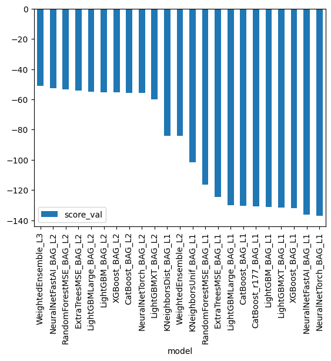

```python
# Output the model's `score_val` in a bar chart to compare performance
predictor.leaderboard(silent=True).plot(kind="bar", x="model", y="score_val")
```

### Create predictions from test dataset

```python
predictions = predictor.predict(test)
predictions.head()
```

```
0    25.677141
1    41.367622
2    45.479092
3    48.383667
4    51.282963
Name: count, dtype: float32
```

#### NOTE: Kaggle will reject the submission if we don't set everything to be > 0.

```python
# Describe the `predictions` series to see if there are any negative values
predictions.describe()
```

```
count    6493.000000
mean      100.959892
std        88.816093
min         2.222307
25%        22.369801
50%        66.739349
75%       169.775360
max       356.442139
Name: count, dtype: float64
```

```python
# How many negative values do we have?
negative_count = (predictions < 0).sum()
print(f"Total negative values in predictions: {negative_count}")
```

```
Total negative values in predictions: 0
```

```python
# Set them to zero
predictions = predictions.apply(lambda x: max(x, 0))
# Check
negative_count_after_set_zero = (predictions < 0).sum()
print(f"Total negative values in predictions after set negative values to zero: {negative_count_after_set_zero}")
```

```
Total negative values in predictions after set negative values to zero: 0
```

### Set predictions to submission dataframe, save, and submit

```python
submission["count"] = predictions
submission.to_csv("submission.csv", index=False)
```

```python
!kaggle competitions submit -c bike-sharing-demand -f submission.csv -m "first raw submission"
```

```
Successfully submitted to Bike Sharing Demand
```

#### View submission via the command line or in the web browser under the competition's page - `My Submissions`

```python
!kaggle competitions submissions -c bike-sharing-demand | tail -n +1 | head -n 6
```

```
submission.csv               2025-03-02 22:01:46  first raw submission               complete  1.76766      1.76766
```

#### Initial score of `1.76766`

## Step 4: Exploratory Data Analysis and Creating an additional feature

- Any additional feature will do, but a great suggestion would be to separate out the datetime into hour, day, or month parts.

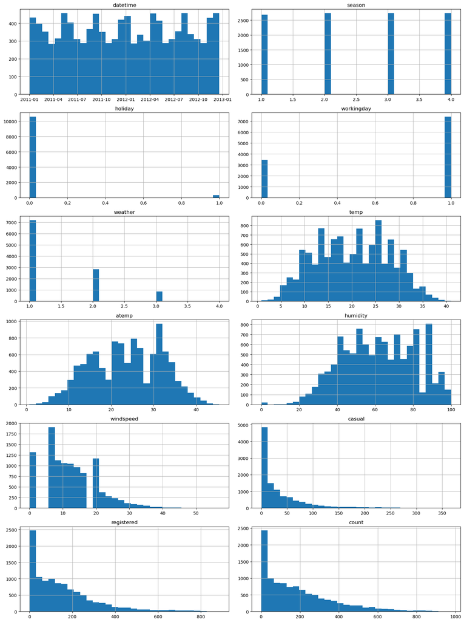

```python
# Create a histogram of all features to show the distribution of each one relative to the data. This is part of the exploritory data analysis
fig, axes = plt.subplots(6, 2, figsize=(15, 20))
axes = axes.flatten()

# Plot histograms for each column
for i, col in enumerate(train.columns):
    train[col].hist(ax=axes[i], bins=30)
    axes[i].set_title(col)

plt.tight_layout()
plt.show()
```

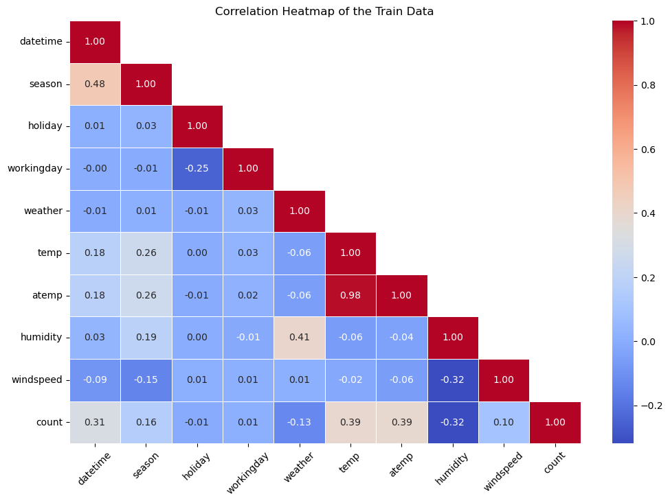

```python
# Plot a correaltion heatmap

# Compute the corr. matrix
corr_matrix = train.drop(['casual', 'registered'], axis=1).corr() # Ignoring 'casual' and 'registered'

# Plot the heatmap
plt.figure(figsize=(12, 8))
corr_mask = np.array(corr_matrix)
corr_mask[np.tril_indices_from(corr_mask)] = False
sns.heatmap(corr_matrix, mask=corr_mask, annot=True, fmt=".2f", cmap="coolwarm", linewidths=0.5)
plt.xticks(rotation=45)
plt.title("Correlation Heatmap of the Train Data")
plt.autoscale()
plt.show()
```

```python
# Drop highly correlated feature 'atemp'
train.drop(["atemp"], axis=1, inplace=True)
test.drop(["atemp"], axis=1, inplace=True)
```

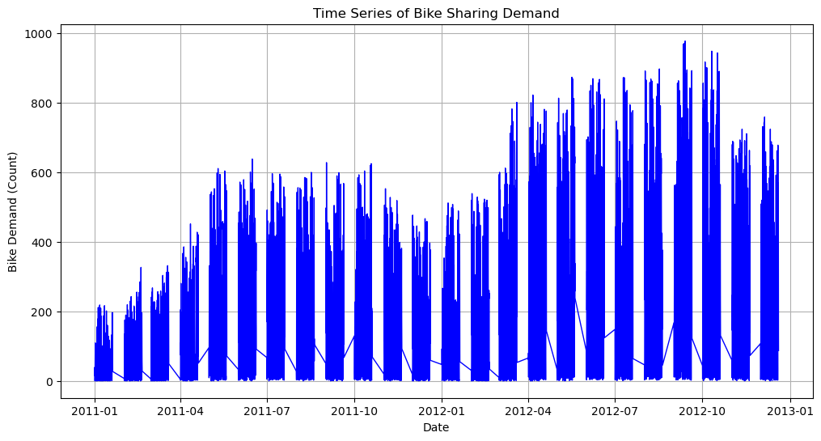

```python
# Plot time series of bike sharing demand ('count')
plt.figure(figsize=(12, 6))
plt.plot(train["datetime"], train["count"], label="Bike Demand", color="blue", linewidth=1)
plt.xlabel("Date")
plt.ylabel("Bike Demand (Count)")
plt.title("Time Series of Bike Sharing Demand")
plt.grid(True)
plt.show()
```

```python
# create a new feature
# Ensure datetime column is in datetime format
train['datetime'] = pd.to_datetime(train['datetime'])
test['datetime'] = pd.to_datetime(test['datetime'])

# Extract features from datetime
for df in [train, test]:
    df['year'] = df['datetime'].dt.year
    df['month'] = df['datetime'].dt.month
    df['day'] = df['datetime'].dt.day
    df['hour'] = df['datetime'].dt.hour

# Display updated train dataset
train.head()
```

|  | datetime | season | holiday | workingday | weather | temp | humidity | windspeed | casual | registered | count | year | month | day | hour |
| --- | --- | --- | --- | --- | --- | --- | --- | --- | --- | --- | --- | --- | --- | --- | --- |
| 0 | 2011-01-01 00:00:00 | 1 | 0 | 0 | 1 | 9.84 | 81 | 0.0 | 3 | 13 | 16 | 2011 | 1 | 1 | 0 |
| 1 | 2011-01-01 01:00:00 | 1 | 0 | 0 | 1 | 9.02 | 80 | 0.0 | 8 | 32 | 40 | 2011 | 1 | 1 | 1 |
| 2 | 2011-01-01 02:00:00 | 1 | 0 | 0 | 1 | 9.02 | 80 | 0.0 | 5 | 27 | 32 | 2011 | 1 | 1 | 2 |
| 3 | 2011-01-01 03:00:00 | 1 | 0 | 0 | 1 | 9.84 | 75 | 0.0 | 3 | 10 | 13 | 2011 | 1 | 1 | 3 |
| 4 | 2011-01-01 04:00:00 | 1 | 0 | 0 | 1 | 9.84 | 75 | 0.0 | 0 | 1 | 1 | 2011 | 1 | 1 | 4 |

```python
train.year.value_counts()
```

```
year
2012    5464
2011    5422
Name: count, dtype: int64
```

```python
train.month.value_counts().sort_index()
```

```
month
1     884
2     901
3     901
4     909
5     912
6     912
7     912
8     912
9     909
10    911
11    911
12    912
Name: count, dtype: int64
```

```python
train.columns
```

```
Index(['datetime', 'season', 'holiday', 'workingday', 'weather', 'temp',
       'humidity', 'windspeed', 'casual', 'registered', 'count', 'year',
       'month', 'day', 'hour'],
      dtype='object')
```

```python
train[['hour', 'temp', 'windspeed', 'humidity']].describe()
```

|  | hour | temp | windspeed | humidity |
| --- | --- | --- | --- | --- |
| count | 10886.000000 | 10886.00000 | 10886.000000 | 10886.000000 |
| mean | 11.541613 | 20.23086 | 12.799395 | 61.886460 |
| std | 6.915838 | 7.79159 | 8.164537 | 19.245033 |
| min | 0.000000 | 0.82000 | 0.000000 | 0.000000 |
| 25% | 6.000000 | 13.94000 | 7.001500 | 47.000000 |
| 50% | 12.000000 | 20.50000 | 12.998000 | 62.000000 |
| 75% | 18.000000 | 26.24000 | 16.997900 | 77.000000 |
| max | 23.000000 | 41.00000 | 56.996900 | 100.000000 |

```python
# Some additional feature engineering

# Feature that categorizes morning, lunch, and evening rush hour, 7-9am, 11am-1pm, and 5-6pm
train["rush_hour"] = train["hour"].apply(lambda x: "morning" if 7 <= x <= 9 else
                                                  "lunch" if 11 <= x <= 13 else
                                                  "evening" if 17 <= x <= 18 else "none")
# Feature that categorizes hot/cold/mild temps from temp
train["temp_category"] = train["temp"].apply(lambda x: "cold" if x < 10 else
                                                      "mild" if 10 <= x <= 26 else "hot")
# Feature that categories very windy/mild wind
train["wind_category"] = train["windspeed"].apply(lambda x: "very_windy" if x > 30 else "mild_wind")
# Feature that categories very humid/ not humid
train["humidity_category"] = train["humidity"].apply(lambda x: "very_humid" if x > 80 else "not_humid")
```

```python
# Apply the same feature engineering to test dataset
test["rush_hour"] = test["hour"].apply(lambda x: "morning" if 7 <= x <= 9 else
                                                  "lunch" if 11 <= x <= 13 else
                                                  "evening" if 17 <= x <= 18 else "none")
test["temp_category"] = test["temp"].apply(lambda x: "cold" if x < 10 else
                                                      "mild" if 10 <= x <= 26 else "hot")
test["wind_category"] = test["windspeed"].apply(lambda x: "very_windy" if x > 30 else "mild_wind")
test["humidity_category"] = test["humidity"].apply(lambda x: "very_humid" if x > 80 else "not_humid")
```

```python
# Create 'is_weekend' feature (0 for weekday, 1 for Saturday/Sunday)
train["is_weekend"] = train["workingday"].apply(lambda x: 0 if x == 1 else 1)
test["is_weekend"] = test["workingday"].apply(lambda x: 0 if x == 1 else 1)
```

## Make category types for these so models know they are not just numbers

- AutoGluon originally sees these as ints, but in reality they are int representations of a category.
- Setting the dtype to category will classify these as categories in AutoGluon.

```python
train["season"] = train["season"].astype("category")
train["weather"] = train["weather"].astype("category")

test["season"] = test["season"].astype("category")
test["weather"] = test["weather"].astype("category")
```

```python
train["is_weekend"] = train["is_weekend"].astype("category")
test["is_weekend"] = test["is_weekend"].astype("category")
```

```python
# View are new feature
print(train.shape)
display(train.head())
```

```
(10886, 20)
```

|  | datetime | season | holiday | workingday | weather | temp | humidity | windspeed | casual | registered | count | year | month | day | hour | rush_hour | temp_category | wind_category | humidity_category | is_weekend |
| --- | --- | --- | --- | --- | --- | --- | --- | --- | --- | --- | --- | --- | --- | --- | --- | --- | --- | --- | --- | --- |
| 0 | 2011-01-01 00:00:00 | 1 | 0 | 0 | 1 | 9.84 | 81 | 0.0 | 3 | 13 | 16 | 2011 | 1 | 1 | 0 | none | cold | mild_wind | very_humid | 1 |
| 1 | 2011-01-01 01:00:00 | 1 | 0 | 0 | 1 | 9.02 | 80 | 0.0 | 8 | 32 | 40 | 2011 | 1 | 1 | 1 | none | cold | mild_wind | not_humid | 1 |
| 2 | 2011-01-01 02:00:00 | 1 | 0 | 0 | 1 | 9.02 | 80 | 0.0 | 5 | 27 | 32 | 2011 | 1 | 1 | 2 | none | cold | mild_wind | not_humid | 1 |
| 3 | 2011-01-01 03:00:00 | 1 | 0 | 0 | 1 | 9.84 | 75 | 0.0 | 3 | 10 | 13 | 2011 | 1 | 1 | 3 | none | cold | mild_wind | not_humid | 1 |
| 4 | 2011-01-01 04:00:00 | 1 | 0 | 0 | 1 | 9.84 | 75 | 0.0 | 0 | 1 | 1 | 2011 | 1 | 1 | 4 | none | cold | mild_wind | not_humid | 1 |

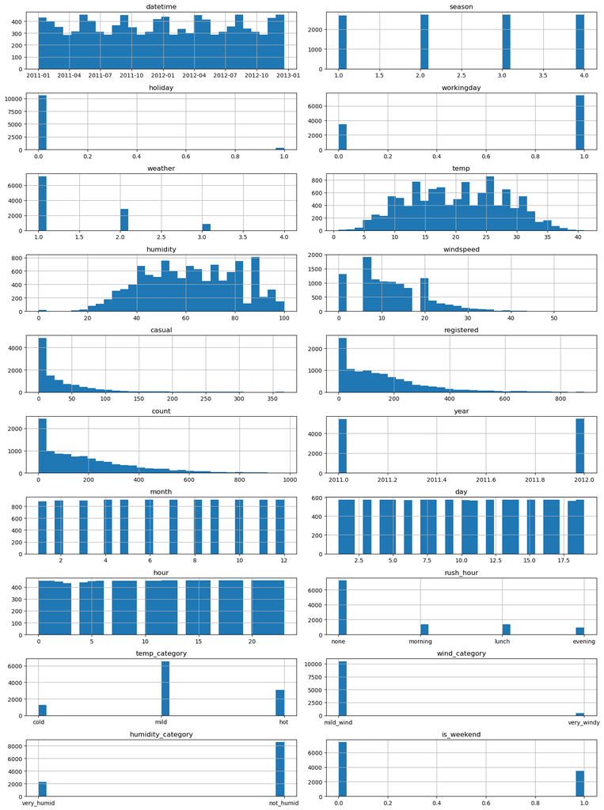

```python
# View histogram of all features again now with the hour feature
fig, axes = plt.subplots(10, 2, figsize=(15, 20))
axes = axes.flatten()

# Plot histograms for each column
for i, col in enumerate(train.columns):
    train[col].hist(ax=axes[i], bins=30)
    axes[i].set_title(col)

plt.tight_layout()
plt.show()
```

## Step 5: Rerun the model with the same settings as before, just with more features

```python
predictor_new_features = TabularPredictor(
    label="count", problem_type="regression", eval_metric="root_mean_squared_error",
    learner_kwargs={'ignored_columns': ["casual", "registered"]}
).fit(
    train_data=train,
    time_limit=600,
    presets="best_quality"
    # presets="high_quality_fast_inference_only_refit",
)
```

[output not shown]

[output cut: 149 more lines]

```
	-30.8827	 = Validation score   (-root_mean_squared_error)
	4.39s	 = Training   runtime
	0.17s	 = Validation runtime
Fitting model: NeuralNetTorch_BAG_L2 ... Training model for up to 13.60s of the 13.56s of remaining time.
	Fitting 8 child models (S1F1 - S1F8) | Fitting with ParallelLocalFoldFittingStrategy (8 workers, per: cpus=1, gpus=0, memory=0.03%)
	-32.0761	 = Validation score   (-root_mean_squared_error)
	13.52s	 = Training   runtime
	0.28s	 = Validation runtime
Fitting model: WeightedEnsemble_L3 ... Training model for up to 360.00s of the -2.65s of remaining time.
	Ensemble Weights: {'NeuralNetFastAI_BAG_L2': 0.6, 'CatBoost_BAG_L2': 0.28, 'XGBoost_BAG_L2': 0.08, 'LightGBM_BAG_L2': 0.04}
	-29.2688	 = Validation score   (-root_mean_squared_error)
	0.08s	 = Training   runtime
	0.0s	 = Validation runtime
AutoGluon training complete, total runtime = 443.17s ... Best model: WeightedEnsemble_L3 | Estimated inference throughput: 109.0 rows/s (1361 batch size)
TabularPredictor saved. To load, use: predictor = TabularPredictor.load("/home/sagemaker-user/project1_bike_sharing_demand/project/AutogluonModels/ag-20250302_225738")
```

```python
predictor_new_features.fit_summary()
```

```
*** Summary of fit() ***
Estimated performance of each model:
                     model   score_val              eval_metric  pred_time_val    fit_time  pred_time_val_marginal  fit_time_marginal  stack_level  can_infer  fit_order
0      WeightedEnsemble_L3  -29.268800  root_mean_squared_error      13.513117  369.941177                0.000747           0.077013            3       True         20
1   NeuralNetFastAI_BAG_L2  -29.607084  root_mean_squared_error      13.112941  295.487585                0.299917          20.515135            2       True         17
2          CatBoost_BAG_L2  -30.185541  root_mean_squared_error      12.884289  341.647669                0.071265          66.675218            2       True         15
3          LightGBM_BAG_L2  -30.616050  root_mean_squared_error      12.973154  278.280309                0.160130           3.307859            2       True         13
4        LightGBMXT_BAG_L2  -30.794745  root_mean_squared_error      13.445879  279.985853                0.632854           5.013403            2       True         12
5           XGBoost_BAG_L2  -30.882685  root_mean_squared_error      12.981060  279.365952                0.168036           4.393502            2       True         18
6     ExtraTreesMSE_BAG_L2  -31.522231  root_mean_squared_error      13.422261  278.391906                0.609237           3.419456            2       True         16
7   RandomForestMSE_BAG_L2  -31.671841  root_mean_squared_error      13.424305  286.915107                0.611281          11.942657            2       True         14
8      WeightedEnsemble_L2  -31.966324  root_mean_squared_error      11.758626  239.699972                0.000723           0.048104            2       True         11
9    NeuralNetTorch_BAG_L2  -32.076129  root_mean_squared_error      13.095599  288.497134                0.282575          13.524683            2       True         19
10         CatBoost_BAG_L1  -33.213570  root_mean_squared_error       0.298767  207.348900                0.298767         207.348900            1       True          6
11         LightGBM_BAG_L1  -33.811385  root_mean_squared_error       2.825770    8.309066                2.825770           8.309066            1       True          4
12          XGBoost_BAG_L1  -34.384791  root_mean_squared_error       0.907398    6.855775                0.907398           6.855775            1       True          9
13       LightGBMXT_BAG_L1  -34.793360  root_mean_squared_error       7.130213   13.076663                7.130213          13.076663            1       True          3
14    ExtraTreesMSE_BAG_L1  -38.028985  root_mean_squared_error       0.545306    2.187441                0.545306           2.187441            1       True          7
15  RandomForestMSE_BAG_L1  -38.837842  root_mean_squared_error       0.561602    4.031513                0.561602           4.031513            1       True          5
16  NeuralNetFastAI_BAG_L1  -52.033449  root_mean_squared_error       0.311240   20.597885                0.311240          20.597885            1       True          8
17   NeuralNetTorch_BAG_L1  -64.137409  root_mean_squared_error       0.163543   12.501437                0.163543          12.501437            1       True         10
18   KNeighborsDist_BAG_L1  -84.125061  root_mean_squared_error       0.034153    0.029952                0.034153           0.029952            1       True          2
19   KNeighborsUnif_BAG_L1 -101.546199  root_mean_squared_error       0.035032    0.033819                0.035032           0.033819            1       True          1
Number of models trained: 20
Types of models trained:
{'StackerEnsembleModel_XGBoost', 'StackerEnsembleModel_XT', 'WeightedEnsembleModel', 'StackerEnsembleModel_LGB', 'StackerEnsembleModel_RF', 'StackerEnsembleModel_TabularNeuralNetTorch', 'StackerEnsembleModel_KNN', 'StackerEnsembleModel_CatBoost', 'StackerEnsembleModel_NNFastAiTabular'}
Bagging used: True  (with 8 folds)
Multi-layer stack-ensembling used: True  (with 3 levels)
Feature Metadata (Processed):
(raw dtype, special dtypes):
('category', [])             : 4 | ['season', 'weather', 'rush_hour', 'temp_category']
('float', [])                : 2 | ['temp', 'windspeed']
('int', [])                  : 4 | ['humidity', 'month', 'day', 'hour']
('int', ['bool'])            : 5 | ['holiday', 'workingday', 'year', 'wind_category', 'humidity_category']
('int', ['datetime_as_int']) : 3 | ['datetime', 'datetime.year', 'datetime.dayofweek']
*** End of fit() summary ***
```

[output not shown]

[output cut: 219 more lines]

```
 5             2       True         18
 6             2       True         16
 7             2       True         14
 8             2       True         11
 9             2       True         19
 10            1       True          6
 11            1       True          4
 12            1       True          9
 13            1       True          3
 14            1       True          7
 15            1       True          5
 16            1       True          8
 17            1       True         10
 18            1       True          2
 19            1       True          1  }
```

```python
# Display the leaderboard summary table
leaderboard_new_features = pd.DataFrame(predictor_new_features.leaderboard(silent=True))
leaderboard_new_features
```

|  | model | score_val | eval_metric | pred_time_val | fit_time | pred_time_val_marginal | fit_time_marginal | stack_level | can_infer | fit_order |
| --- | --- | --- | --- | --- | --- | --- | --- | --- | --- | --- |
| 0 | WeightedEnsemble_L3 | -29.268800 | root_mean_squared_error | 13.513117 | 369.941177 | 0.000747 | 0.077013 | 3 | True | 20 |
| 1 | NeuralNetFastAI_BAG_L2 | -29.607084 | root_mean_squared_error | 13.112941 | 295.487585 | 0.299917 | 20.515135 | 2 | True | 17 |
| 2 | CatBoost_BAG_L2 | -30.185541 | root_mean_squared_error | 12.884289 | 341.647669 | 0.071265 | 66.675218 | 2 | True | 15 |
| 3 | LightGBM_BAG_L2 | -30.616050 | root_mean_squared_error | 12.973154 | 278.280309 | 0.160130 | 3.307859 | 2 | True | 13 |
| 4 | LightGBMXT_BAG_L2 | -30.794745 | root_mean_squared_error | 13.445879 | 279.985853 | 0.632854 | 5.013403 | 2 | True | 12 |
| 5 | XGBoost_BAG_L2 | -30.882685 | root_mean_squared_error | 12.981060 | 279.365952 | 0.168036 | 4.393502 | 2 | True | 18 |
| 6 | ExtraTreesMSE_BAG_L2 | -31.522231 | root_mean_squared_error | 13.422261 | 278.391906 | 0.609237 | 3.419456 | 2 | True | 16 |
| 7 | RandomForestMSE_BAG_L2 | -31.671841 | root_mean_squared_error | 13.424305 | 286.915107 | 0.611281 | 11.942657 | 2 | True | 14 |
| 8 | WeightedEnsemble_L2 | -31.966324 | root_mean_squared_error | 11.758626 | 239.699972 | 0.000723 | 0.048104 | 2 | True | 11 |
| 9 | NeuralNetTorch_BAG_L2 | -32.076129 | root_mean_squared_error | 13.095599 | 288.497134 | 0.282575 | 13.524683 | 2 | True | 19 |
| 10 | CatBoost_BAG_L1 | -33.213570 | root_mean_squared_error | 0.298767 | 207.348900 | 0.298767 | 207.348900 | 1 | True | 6 |
| 11 | LightGBM_BAG_L1 | -33.811385 | root_mean_squared_error | 2.825770 | 8.309066 | 2.825770 | 8.309066 | 1 | True | 4 |
| 12 | XGBoost_BAG_L1 | -34.384791 | root_mean_squared_error | 0.907398 | 6.855775 | 0.907398 | 6.855775 | 1 | True | 9 |
| 13 | LightGBMXT_BAG_L1 | -34.793360 | root_mean_squared_error | 7.130213 | 13.076663 | 7.130213 | 13.076663 | 1 | True | 3 |
| 14 | ExtraTreesMSE_BAG_L1 | -38.028985 | root_mean_squared_error | 0.545306 | 2.187441 | 0.545306 | 2.187441 | 1 | True | 7 |
| 15 | RandomForestMSE_BAG_L1 | -38.837842 | root_mean_squared_error | 0.561602 | 4.031513 | 0.561602 | 4.031513 | 1 | True | 5 |
| 16 | NeuralNetFastAI_BAG_L1 | -52.033449 | root_mean_squared_error | 0.311240 | 20.597885 | 0.311240 | 20.597885 | 1 | True | 8 |
| 17 | NeuralNetTorch_BAG_L1 | -64.137409 | root_mean_squared_error | 0.163543 | 12.501437 | 0.163543 | 12.501437 | 1 | True | 10 |
| 18 | KNeighborsDist_BAG_L1 | -84.125061 | root_mean_squared_error | 0.034153 | 0.029952 | 0.034153 | 0.029952 | 1 | True | 2 |
| 19 | KNeighborsUnif_BAG_L1 | -101.546199 | root_mean_squared_error | 0.035032 | 0.033819 | 0.035032 | 0.033819 | 1 | True | 1 |

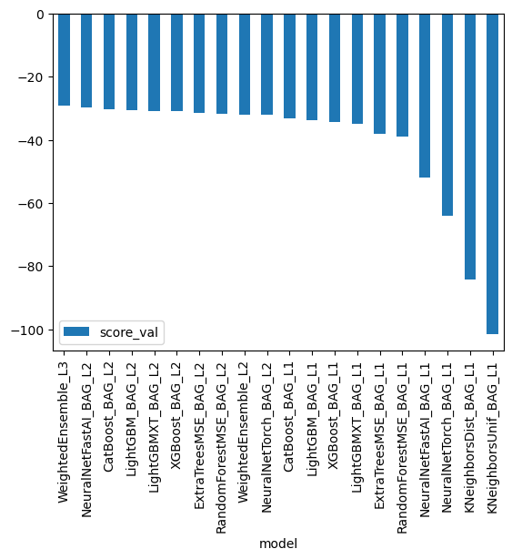

```python
# Output the model's `score_val` in a bar chart to compare performance
predictor_new_features.leaderboard(silent=True).plot(kind="bar", x="model", y="score_val")
```

### Create predictions from test dataset

```python
predictions_new_features = predictor_new_features.predict(test)
print(predictions_new_features.shape)
display(predictions_new_features.head())
```

```
(6493,)
```

```
0    17.224840
1    11.431989
2    10.989016
3    11.324799
4    10.986503
Name: count, dtype: float32
```

```python
# Check
negative_count_new_features = (predictions_new_features < 0).sum()
print(f"Total negative values in predictions (with new features): {negative_count_new_features}")

# Remember to set all negative values to zero
predictions_new_features = predictions_new_features.apply(lambda x: max(x, 0))

# Check
negative_count_new_features_after_set_zero = (predictions < 0).sum()
print(f"Total negative values in predictions (with new features) after set negative values to zero: {negative_count_new_features_after_set_zero}")
```

```
Total negative values in predictions (with new features): 0
Total negative values in predictions (with new features) after set negative values to zero: 0
```

### Set predictions to submission dataframe, save, and submit

```python
# Same submitting predictions
submission_new_features = submission.copy()
submission_new_features["count"] = predictions_new_features
submission_new_features.to_csv("submission_new_features.csv", index=False)
```

```python
!kaggle competitions submit -c bike-sharing-demand -f submission_new_features.csv -m "new features"
```

```
Successfully submitted to Bike Sharing Demand
```

```python
!kaggle competitions submissions -c bike-sharing-demand | tail -n +1 | head -n 6
```

```
fileName                     date                 description                        status    publicScore  privateScore
---------------------------  -------------------  ---------------------------------  --------  -----------  ------------
submission_new_features.csv  2025-03-02 23:07:59  new features                       complete  0.80239      0.80239
submission_new_hpo.csv       2025-03-02 22:34:32  new features with hyperparameters  complete  0.54062      0.54062
submission_new_features.csv  2025-03-02 22:33:41  new features                       complete  0.69854      0.69854
submission.csv               2025-03-02 22:01:46  first raw submission               complete  1.76766      1.76766
```

#### New Score of `0.80239`

## Step 6: Hyper parameter optimization

- There are many options for hyper parameter optimization.
- Options are to change the AutoGluon higher level parameters or the individual model hyperparameters.
- The hyperparameters of the models themselves that are in AutoGluon. Those need the `hyperparameter` and `hyperparameter_tune_kwargs` arguments.

```python
from autogluon.tabular import TabularPredictor
from autogluon.common import space
```

```python
# Define hyperparameter search space
nn_options = {
    'num_epochs': [3, 5, 10],
    'learning_rate': space.Real(0.0001, 0.01, default=5e-4, log=True),
    'activation': space.Categorical('relu', 'softrelu', 'tanh'),
    'dropout_prob': space.Real(0.0, 0.5, default=0.1)
}

gbm_options = [
    {"num_leaves": [20, 40, 60],
     'extra_trees': True,
     "learning_rate": [0.01, 0.05, 0.1],
     'num_boost_round': space.Int(lower=100, upper=500, default=100),
     'num_leaves': space.Int(lower=25, upper=64, default=36),
     'ag_args': {'name_suffix': 'XT'}},
    {},
    'GBMLarge'
]

xgb_options = {"n_estimators": [100, 300], "max_depth": [3, 6]}
cat_options = {"depth": [6, 8, 10], "learning_rate": [0.01, 0.05, 0.1]}
```

```python
# Define hyperparameters
hyperparameters = {
    'GBM': gbm_options,
    'NN_TORCH': nn_options,
    "XGB": xgb_options,
    "CAT": cat_options
}

# Hyperparameter tuning settings
hyperparameter_tune_kwargs = {
    'num_trials': 10, 'scheduler': 'auto', 'searcher': 'local'
}
```

```python
# Train model with hyperparameter tuning
predictor_new_hpo = TabularPredictor(
    label='count',
    problem_type='regression',
    eval_metric='root_mean_squared_error',
    learner_kwargs={'ignored_columns': ["casual", "registered"]}
).fit(
    train_data=train,
    time_limit=900,
    presets="best_quality",
    # presets="high_quality_fast_inference_only_refit",
    hyperparameters=hyperparameters,
    hyperparameter_tune_kwargs=hyperparameter_tune_kwargs,
    refit_full='best'
)
```

[output not shown]

[output cut: 288 more lines]

```
	Ensemble Weights: {'LightGBMLarge_BAG_L1': 1.0}
	-33.4481	 = Validation score   (-root_mean_squared_error)
	0.01s	 = Training   runtime
	0.0s	 = Validation runtime
AutoGluon training complete, total runtime = 20.18s ... Best model: WeightedEnsemble_L2 | Estimated inference throughput: 679.0 rows/s (1361 batch size)
Automatically performing refit_full as a post-fit operation (due to `.fit(..., refit_full=True)`
Refitting models via `predictor.refit_full` using all of the data (combined train and validation)...
	Models trained in this way will have the suffix "_FULL" and have NaN validation score.
	This process is not bound by time_limit, but should take less time than the original `predictor.fit` call.
	To learn more, refer to the `.refit_full` method docstring which explains how "_FULL" models differ from normal models.
Fitting 1 L1 models, fit_strategy="sequential" ...
Fitting model: LightGBMLarge_BAG_L1_FULL ...
	2.71s	 = Training   runtime
Refit complete, total runtime = 3.47s ... Best model: "WeightedEnsemble_L2"
TabularPredictor saved. To load, use: predictor = TabularPredictor.load("/home/sagemaker-user/project1_bike_sharing_demand/project/AutogluonModels/ag-20250302_231013")
```

```python
predictor_new_hpo.fit_summary()
```

```
*** Summary of fit() ***
Estimated performance of each model:
                       model  score_val              eval_metric  pred_time_val   fit_time  pred_time_val_marginal  fit_time_marginal  stack_level  can_infer  fit_order
0       LightGBMLarge_BAG_L1 -33.448057  root_mean_squared_error       2.004257   9.095201                2.004257           9.095201            1       True          1
1        WeightedEnsemble_L2 -33.448057  root_mean_squared_error       2.004774   9.097795                0.000517           0.002593            2       True          2
2        WeightedEnsemble_L3 -33.448057  root_mean_squared_error       2.004802   9.104096                0.000545           0.008895            3       True          4
3       LightGBMLarge_BAG_L2 -35.814691  root_mean_squared_error       2.187850  12.804006                0.183594           3.708804            2       True          3
4  LightGBMLarge_BAG_L1_FULL        NaN  root_mean_squared_error            NaN   2.709046                     NaN           2.709046            1       True          5
Number of models trained: 5
Types of models trained:
{'WeightedEnsembleModel', 'StackerEnsembleModel_LGB'}
Bagging used: True  (with 8 folds)
Multi-layer stack-ensembling used: True  (with 3 levels)
Feature Metadata (Processed):
(raw dtype, special dtypes):
('category', [])             : 4 | ['season', 'weather', 'rush_hour', 'temp_category']
('float', [])                : 2 | ['temp', 'windspeed']
('int', [])                  : 4 | ['humidity', 'month', 'day', 'hour']
('int', ['bool'])            : 5 | ['holiday', 'workingday', 'year', 'wind_category', 'humidity_category']
('int', ['datetime_as_int']) : 3 | ['datetime', 'datetime.year', 'datetime.dayofweek']
*** End of fit() summary ***
```

[output not shown]

[output cut: 18 more lines]

```
 4  LightGBMLarge_BAG_L1_FULL        NaN  root_mean_squared_error

    pred_time_val   fit_time  pred_time_val_marginal  fit_time_marginal  \
 0       2.004257   9.095201                2.004257           9.095201
 1       2.004774   9.097795                0.000517           0.002593
 2       2.004802   9.104096                0.000545           0.008895
 3       2.187850  12.804006                0.183594           3.708804
 4            NaN   2.709046                     NaN           2.709046

    stack_level  can_infer  fit_order
 0            1       True          1
 1            2       True          2
 2            3       True          4
 3            2       True          3
 4            1       True          5  }
```

```python
# Display the leaderboard summary table
leaderboard_new_hpo = pd.DataFrame(predictor_new_hpo.leaderboard(silent=True))
leaderboard_new_hpo
```

|  | model | score_val | eval_metric | pred_time_val | fit_time | pred_time_val_marginal | fit_time_marginal | stack_level | can_infer | fit_order |
| --- | --- | --- | --- | --- | --- | --- | --- | --- | --- | --- |
| 0 | LightGBMLarge_BAG_L1 | -33.448057 | root_mean_squared_error | 2.004257 | 9.095201 | 2.004257 | 9.095201 | 1 | True | 1 |
| 1 | WeightedEnsemble_L2 | -33.448057 | root_mean_squared_error | 2.004774 | 9.097795 | 0.000517 | 0.002593 | 2 | True | 2 |
| 2 | WeightedEnsemble_L3 | -33.448057 | root_mean_squared_error | 2.004802 | 9.104096 | 0.000545 | 0.008895 | 3 | True | 4 |
| 3 | LightGBMLarge_BAG_L2 | -35.814691 | root_mean_squared_error | 2.187850 | 12.804006 | 0.183594 | 3.708804 | 2 | True | 3 |
| 4 | LightGBMLarge_BAG_L1_FULL | NaN | root_mean_squared_error | NaN | 2.709046 | NaN | 2.709046 | 1 | True | 5 |

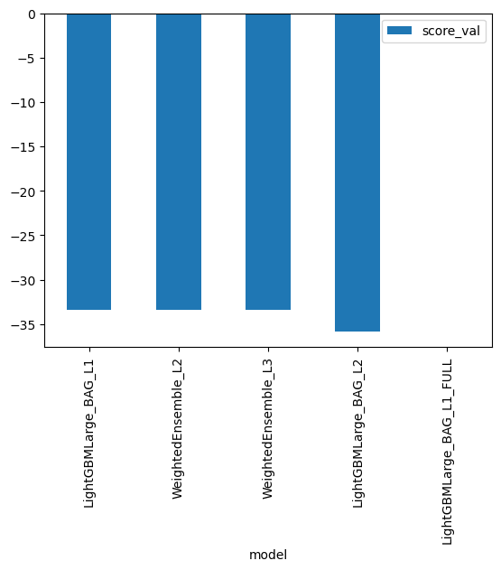

```python
# Output the model's `score_val` in a bar chart to compare performance
predictor_new_hpo.leaderboard(silent=True).plot(kind="bar", x="model", y="score_val")
```

### Create predictions from test dataset

```python
predictions_new_hpo = predictor_new_hpo.predict(test)
print(predictions_new_hpo.shape)
display(predictions_new_hpo.head())
```

```
(6493,)
```

```
0    16.194992
1     3.243011
2     0.539634
3     2.062586
4     2.008295
Name: count, dtype: float32
```

```python
# Check
negative_count_new_hpo = (predictions_new_hpo < 0).sum()
print(f"Total negative values in predictions (HPO): {negative_count_new_hpo}")

# Remember to set all negative values to zero
predictions_new_hpo = predictions_new_hpo.apply(lambda x: max(x, 0))

# Check
negative_count_new_hpo_after_set_zero = (predictions < 0).sum()
print(f"Total negative values in predictions (HPO) after set negative values to zero: {negative_count_new_hpo_after_set_zero}")
```

```
Total negative values in predictions (HPO): 49
Total negative values in predictions (HPO) after set negative values to zero: 0
```

### Set predictions to submission dataframe, save, and submit

```python
# Same submitting predictions
submission_new_hpo = submission.copy()
submission_new_hpo["count"] = predictions_new_hpo
submission_new_hpo.to_csv("submission_new_hpo.csv", index=False)
```

```python
!kaggle competitions submit -c bike-sharing-demand -f submission_new_hpo.csv -m "new features with hyperparameters"
```

```
Successfully submitted to Bike Sharing Demand
```

```python
!kaggle competitions submissions -c bike-sharing-demand | tail -n +1 | head -n 6
```

```
fileName                     date                 description                        status    publicScore  privateScore
---------------------------  -------------------  ---------------------------------  --------  -----------  ------------
submission_new_hpo.csv       2025-03-02 23:11:09  new features with hyperparameters  complete  0.49823      0.49823
submission_new_features.csv  2025-03-02 23:07:59  new features                       complete  0.80239      0.80239
submission_new_hpo.csv       2025-03-02 22:34:32  new features with hyperparameters  complete  0.54062      0.54062
submission_new_features.csv  2025-03-02 22:33:41  new features                       complete  0.69854      0.69854
```

#### New Score of `0.49823`

## Step 7: Write a Report

### Refer to the markdown file for the full report

### Creating plots and table for report

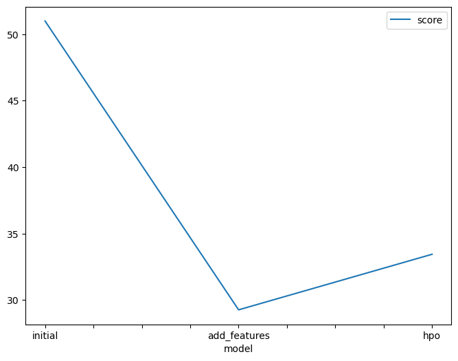

```python
# Taking the top model score from each training run and creating a line plot to show improvement
# You can create these in the notebook and save them to PNG or use some other tool (e.g. google sheets, excel)
fig = pd.DataFrame(
    {
        "model": ["initial", "add_features", "hpo"],
        "score": [50.988460, 29.268800, 33.448057]
    }
).plot(x="model", y="score", figsize=(8, 6)).get_figure()
fig.savefig('model_train_score.png')
```

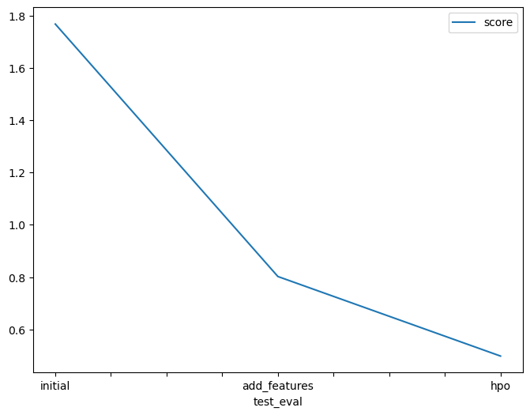

```python
# Take the 3 kaggle scores and creating a line plot to show improvement
fig = pd.DataFrame(
    {
        "test_eval": ["initial", "add_features", "hpo"],
        "score": [1.76766, 0.80239, 0.49823]
    }
).plot(x="test_eval", y="score", figsize=(8, 6)).get_figure()
fig.savefig('model_test_score.png')
```

### Hyperparameter table

```python
# The 3 hyperparameters we tuned with the kaggle score as the result

pd.DataFrame({
    "model": ["initial", "add_features", "hpo"],
    "time_limit": ["600", "600", "900"],
    "nn_learning_rate": ["default", "default", "lower=0.0001, upper=0.01"],
    "num_boost_round": ["default", "default", "lower=100, upper=500"],
    "cat_depth": ["default", "default", "[6, 8, 10]"],
    "...": ["default", "default", "..."],
    "score": [1.76766, 0.80239, 0.49823]
})
```

|  | model | time_limit | nn_learning_rate | num_boost_round | cat_depth | ... | score |
| --- | --- | --- | --- | --- | --- | --- | --- |
| 0 | initial | 600 | default | default | default | default | 1.76766 |
| 1 | add_features | 600 | default | default | default | default | 0.80239 |
| 2 | hpo | 900 | lower=0.0001, upper=0.01 | lower=100, upper=500 | [6, 8, 10] | ... | 0.49823 |